# Honduras2 Summary Report

02/04/2026

## Resumen de la encuesta

| Forma | N |
| --- | --- |
| Formulario de indicadores | 82 |
| Forma femenina | 92 |
| Completó ambos formularios | 80 |
| Formulario de indicador completado únicamente | 2 |
| Formulario completado únicamente para mujeres | 12 |

## Muestra de datos demográficos

| **Característica** | **N = 82**<sup>1</sup> |
| --- | --- |
| loc1_name |  |
| Guacimal #1 | 8 (9.8%) |
| Guacimal #2 | 7 (8.5%) |
| Guanacaste | 1 (1.2%) |
| La Cañita | 6 (7.3%) |
| La Pintura | 7 (8.5%) |
| Los Chavarria | 8 (9.8%) |
| Los Encuentros | 8 (9.8%) |
| Marías Del Pacon | 9 (11%) |
| Monte Oscuro | 6 (7.3%) |
| Nance Dulce | 7 (8.5%) |
| Pintadas | 7 (8.5%) |
| Pintadillo | 8 (9.8%) |
| Sexo del encuestado |  |
| F | 22 (27%) |
| M | 60 (73%) |
| Edad del encuestado | 51 (40, 60) |
| Formulario de mujeres Edad del encuestado | 48 (39, 58) |
| Educación (Jefe de hogar) |  |
| No hay escuela | 8 (9.8%) |
| Primario | 65 (79%) |
| Secundario | 5 (6.1%) |
| Postsecundaria | 0 (0%) |
| Educación de adultos, escuela de alfabetización o escuela parroquial | 1 (1.2%) |
| Sin respuesta | 3 (3.7%) |

<sup>1</sup> n (%); Median (Q1, Q3)

## Indicator Summary

| Indicador | Estimar |
| --- | --- |
| PO.1 |  |
| Número total de cultivos (Mediana) | 4 |
| Número total de cultivos importantes (Mediana) | 2 |
| Índice de diversidad de Gini-Simpson (Mediana) | 0.21 |
| Porcentaje promedio de superficie agrícola utilizada para la producción de cultivos básicos (mijo, maíz, sorgo y trigo) | 54.0% |
| PO.2 |  |
| Toma de decisiones de las mujeres: Cultivos para la alimentación | 82.2% |
| Toma de decisiones de las mujeres: Cultivos para el mercado | 80.0% |
| Toma de decisiones de las mujeres: Gasto de los ahorros del hogar | 82.6% |
| Toma de decisiones de las mujeres: Elegir cómo gastar sus propios ingresos | 65.2% |
| Toma de decisiones de las mujeres: Elegir qué vender en el mercado | 58.1% |
| Toma de decisiones de las mujeres: Participar en comités comunitarios; específicamente, ¿pueden elegir cómo asignar su tiempo a grupos comunitarios, trabajo agrícola, etc.? | 90.6% |
| % de mujeres que poseen propiedad exclusiva o conjunta de al menos un activo importante o dos menores: | 100.0% |
| Porcentaje promedio de activos del hogar que son propiedad exclusiva o conjunta de mujeres | 100.0% |
| PO.3 |  |
| % de hogares con al menos 2 fuentes de ingresos diferentes | 18.3% |
| Situación financiera: “Podemos comprar todo lo que queramos y aún queda dinero para posibles ahorros” | 42.7% |
| ¿Su hogar tiene algún crédito, deudas o préstamos, o tuvo alguno en los últimos 12 meses? | 52.4% |
| ¿Alguna vez le resultó difícil pagar las deudas en los últimos 12 meses? | 35.4% |
| PO.4 |  |
| Diversidad dietética mínima (5 grupos de alimentos) | 100.0% |
| Porcentaje estimado de hogares con inseguridad alimentaria moderada o grave: | 60.8% |
| Porcentaje estimado de hogares con inseguridad alimentaria grave: | 4.5% |

## PO.1 Productividad

**Definición objetiva** : Los hogares de pequeños agricultores han mejorado su capacidad para aumentar la productividad y la seguridad alimentaria mediante la transición de sus sistemas agrícolas a métodos agroecológicos.

### Producción de cultivos

| Cultivo | N (%) | Área media (Ha) | Rendimiento medio (kg) | Productividad media (kg/ha) |
| --- | --- | --- | --- | --- |
| Maíz | 75 (91.5%) | 1.23 | 1,215 | 1,194 |
| Frjoles colarados | 61 (74.4%) | 0.84 | 253 | 314 |
| Frijoles alacines | 25 (30.5%) | 0.33 | 45 | 110 |
| Guineos | 3 (3.7%) | 7.40 |  |  |

Las entradas faltantes son resultado de utilizar unidades de medida sin confirmado conversiones a KG y/o HA

**Número de cultivos cultivados en una granja**

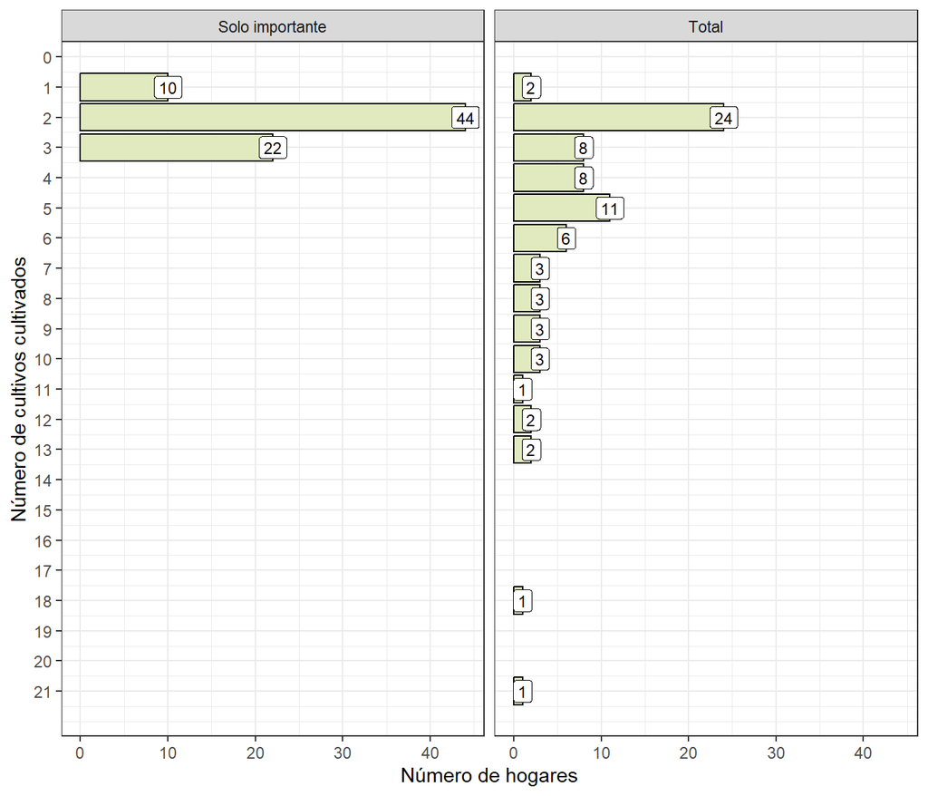

**Superficie de cultivos principales (Ha)**

El siguiente diagrama de caja muestra la distribución de las áreas de producción agrícola (en hectáreas) para todos los cultivos cultivados por al menos 5 encuestados. La caja representa el rango intercuartílico (RIC) de los datos, y la línea dentro de la caja indica la mediana. Los bigotes se extienden hasta 1,5 veces el RIC, y cualquier punto fuera de este rango se considera un valor atípico y no se muestra en este gráfico.

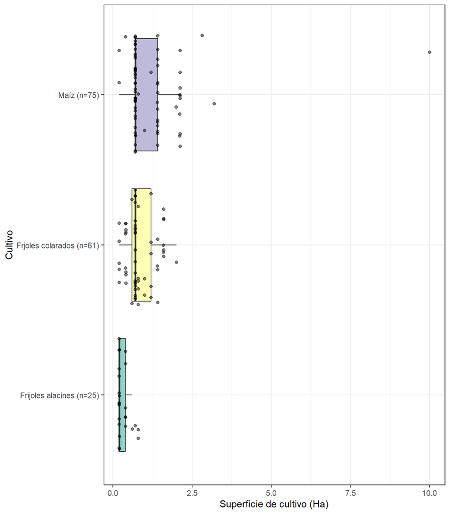

**Rendimiento de los cultivos (kg/ha)**

El siguiente diagrama de caja muestra la distribución de los rendimientos de los cultivos (en kg/ha) para todos los cultivos sembrados por al menos 5 encuestados. La caja representa el rango intercuartílico (RIC) de los datos, y la línea dentro de la caja indica la mediana. Los bigotes se extienden hasta 1,5 veces el RIC, y cualquier punto que se encuentre fuera de este rango se considera un valor atípico y no se muestra en este gráfico.

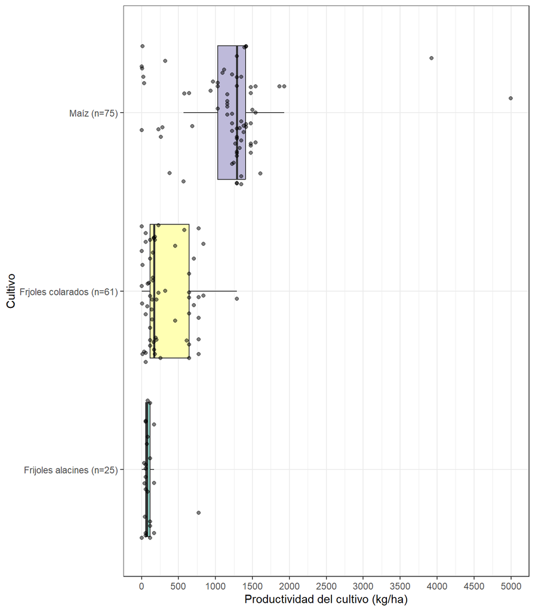

## PO.2 Empoderamiento de las mujeres

**Definición objetiva** : Las mujeres agricultoras han adquirido un mayor control sobre los recursos productivos y la toma de decisiones en sus hogares y comunidades.

**Proporción de hogares donde las mujeres tienen igual o mayor influencia o voz sobre…**

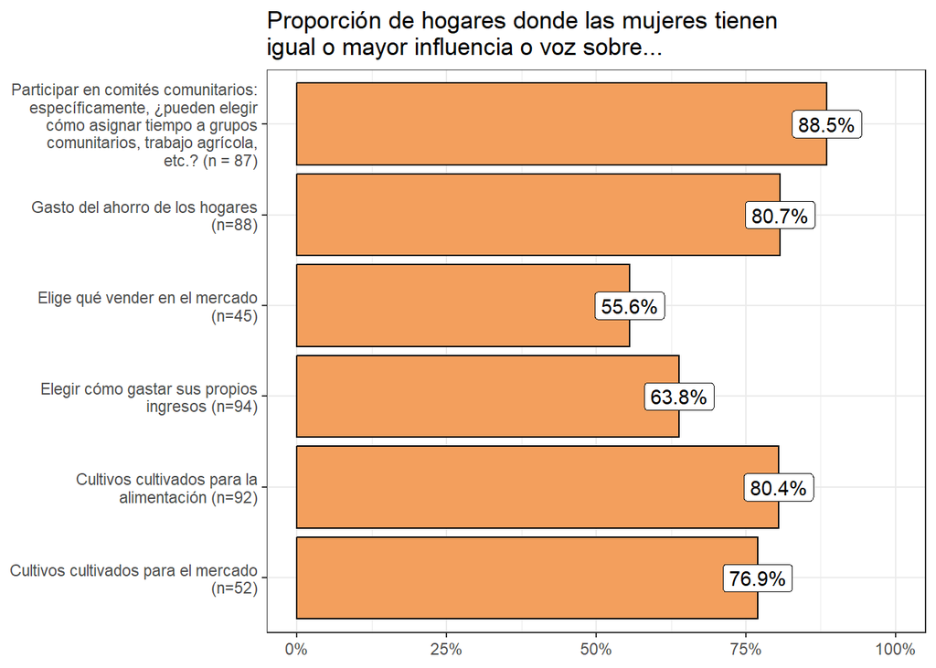

**A-WEAI - Acceso al capital productivo**

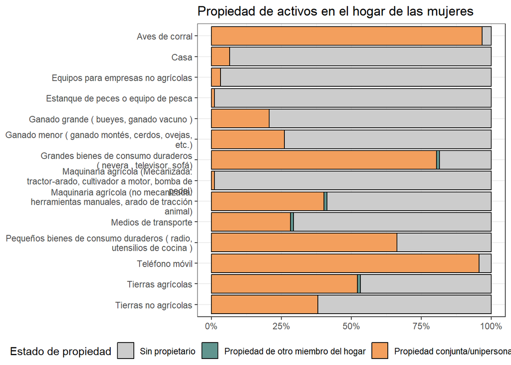

| Asset | Propiedad conjunta/unipersonal | Sin propietario | Propiedad de otro miembro del hogar |
| --- | --- | --- | --- |
| Tierras agrícolas | 52.2% | 46.7% | 1.1% |
| Ganado grande ( bueyes, ganado vacuno ) | 20.7% | 79.3% | 0.0% |
| Ganado menor ( ganado montés, cerdos, ovejas, etc.) | 26.1% | 73.9% | 0.0% |
| Aves de corral | 96.7% | 3.3% | 0.0% |
| Estanque de peces o equipo de pesca | 1.1% | 98.9% | 0.0% |
| Maquinaria agrícola (no mecanizada: herramientas manuales, arado de tracción animal) | 40.2% | 58.7% | 1.1% |
| Maquinaria agrícola (Mecanizada: tractor-arado, cultivador a motor, bomba de pedal) | 1.1% | 98.9% | 0.0% |
| Equipos para empresas no agrícolas | 3.3% | 96.7% | 0.0% |
| Casa | 6.5% | 93.5% | 0.0% |
| Grandes bienes de consumo duraderos ( nevera , televisor, sofá) | 80.4% | 18.5% | 1.1% |
| Pequeños bienes de consumo duraderos ( radio, utensilios de cocina ) | 66.3% | 33.7% | 0.0% |
| Teléfono móvil | 95.7% | 4.3% | 0.0% |
| Tierras no agrícolas | 38.0% | 62.0% | 0.0% |
| Medios de transporte | 28.3% | 70.7% | 1.1% |

## PO.3 Ingresos del hogar

**Definición objetiva** : Los hogares de pequeños agricultores han aumentado de manera sostenible sus ingresos y diversificado sus medios de vida con énfasis en los mercados locales.

### Mercados

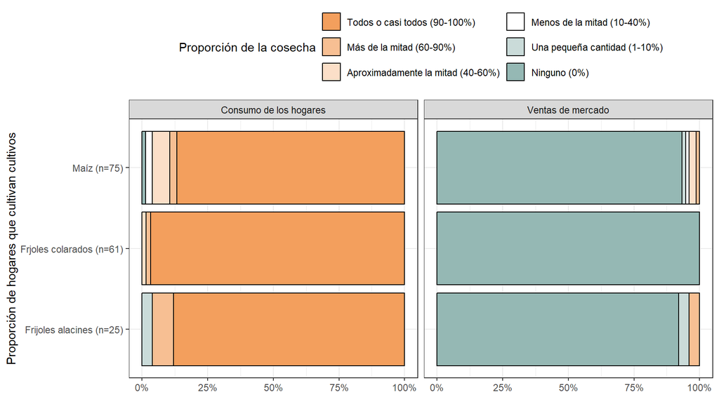

|  | **Frijoles alacines** N = 25<sup>1</sup> | **Frjoles colarados** N = 61<sup>1</sup> | **Maíz** N = 75<sup>1</sup> |
| --- | --- | --- | --- |
| Consumo de los hogares |  |  |  |
| Todos o casi todos (90-100%) | 22 (88%) | 59 (97%) | 65 (87%) |
| Más de la mitad (60-90%) | 2 (8.0%) | 1 (1.6%) | 2 (2.7%) |
| Aproximadamente la mitad (40-60%) | 0 (0%) | 1 (1.6%) | 5 (6.7%) |
| Menos de la mitad (10-40%) | 0 (0%) | 0 (0%) | 2 (2.7%) |
| Una pequeña cantidad (1-10%) | 1 (4.0%) | 0 (0%) | 0 (0%) |
| Ninguno (0%) | 0 (0%) | 0 (0%) | 1 (1.3%) |
| Sin respuesta | 0 (0%) | 0 (0%) | 0 (0%) |
| Ventas de mercado |  |  |  |
| Todos o casi todos (90-100%) | 0 (0%) | 0 (0%) | 0 (0%) |
| Más de la mitad (60-90%) | 1 (4.0%) | 0 (0%) | 1 (1.3%) |
| Aproximadamente la mitad (40-60%) | 0 (0%) | 0 (0%) | 2 (2.7%) |
| Menos de la mitad (10-40%) | 0 (0%) | 0 (0%) | 1 (1.3%) |
| Una pequeña cantidad (1-10%) | 1 (4.0%) | 0 (0%) | 1 (1.3%) |
| Ninguno (0%) | 23 (92%) | 61 (100%) | 70 (93%) |
| Sin respuesta | 0 (0%) | 0 (0%) | 0 (0%) |

<sup>1</sup> n (%)

### Diversificación de ingresos

**Diversidad e importancia de las fuentes de ingresos**

| **Characteristic** | **N = 94**<sup>1</sup> |
| --- | --- |
| Fuente de ingresos |  |
| Crop farming + Off-farm sources | 15 (18%) |
| Crop farming only | 63 (77%) |
| Income sources unreported | 4 (4.9%) |
| Unknown | 12 |

<sup>1</sup> n (%)

| Fuente de ingresos | Hogares (n) | % |
| --- | --- | --- |
| Trabajo, no en una granja | 1 | 1.2% |
| Tener mi propio negocio | 9 | 11.0% |
| Remesas (enviar dinero) | 4 | 4.9% |
| Trabajar para el gobierno o institución pública | 1 | 1.2% |

### Capacidad de ahorrar y pagar deudas

Hogares que informan de su situación financiera como “Podemos comprar todo lo que queremos y aún hay dinero para posibles ahorros”: 42.7%

¿Su hogar tiene algún crédito, deudas o préstamos, o tuvo alguno en los últimos 12 meses? 52.4%

¿Alguna vez le resultó difícil pagar las deudas en los últimos 12 meses?: 35.4%

### Autopercepción de la situación financiera

|  | **N = 82**<sup>1</sup> |
| --- | --- |
| Autopercepción de la situación financiera |  |
| Podemos comprar todo lo que queramos y aún queda dinero para posibles ahorros. | 35 (43%) |
| Podemos comprar todo lo que queramos sin problemas específicos pero no somos capaces de ahorrar | 35 (43%) |
| Vivimos económicamente y por eso podemos permitirnos todo. | 8 (9.8%) |
| Vivimos muy económicamente para ahorrar dinero para compras / eventos importantes. | 3 (3.7%) |
| Podemos comprar sólo la comida y la ropa más baratas y alquilar el apartamento más barato y (si la familia está endeudada) para pagar el préstamo. | 0 (0%) |
| Sólo podemos comprar la comida más barata y no tenemos dinero para devolver el préstamo ni para pagar ropa nueva o el alquiler. | 0 (0%) |
| No podemos permitirnos ni siquiera la comida más barata. | 1 (1.2%) |

<sup>1</sup> n (%)

## PO.4 Seguridad alimentaria y diversidad dietética

**Definición objetiva** : Los hogares vulnerables han mejorado la diversidad dietética y el estado nutricional.

### Diversidad dietética en el hogar

La diversidad alimentaria del hogar se define preguntando a la persona encuestada cuáles de los siguientes 12 grupos de alimentos consumió en las últimas 24 horas: cereales, raíces y tubérculos, legumbres, verduras, frutas, carne y aves, huevos, pescado y mariscos, leche y productos lácteos, aceites y grasas, dulces envasados o miel y otros. Las puntuaciones oscilarán entre 0 y 12. Una puntuación de 0 indicaría que el hogar pasó un día entero sin comer, mientras que una puntuación de 12 sugiere que se consumieron todos los grupos de alimentos mencionados.

Nota: Durante la fase piloto de Groundswell, estas preguntas solo incluían a la mujer que respondía en el hogar. En futuras implementaciones, se incluirá a todo el hogar.

% Hogares que alcanzaron el nivel mínimo de diversidad (al menos 5 grupos de alimentos): 100.0%

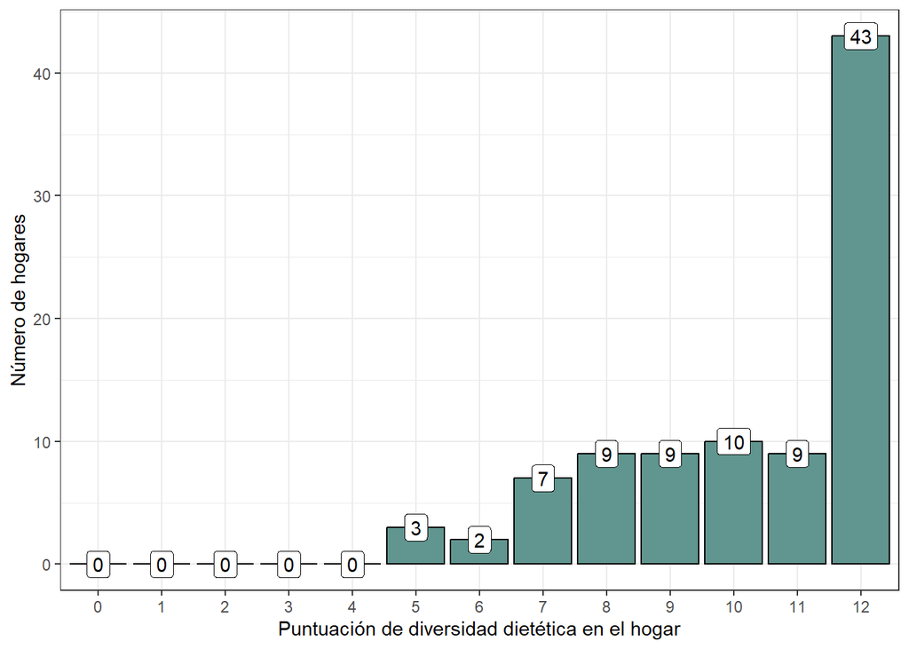

### FIES (Inseguridad alimentaria)

La Escala de Experiencia de Inseguridad Alimentaria (FIES, por sus siglas en inglés) evalúa el historial reciente de seguridad alimentaria de un hogar mediante 8 preguntas. Para cada pregunta, la mujer que responde indicará si el hogar experimentó ciertos eventos debido a la falta de dinero o recursos en los últimos 12 meses. Estos incluyen no poder consumir alimentos saludables, saltarse comidas y pasar un día entero sin comer.

Cada comportamiento experimentado incrementa la puntuación FIES en 1; por lo tanto, las puntuaciones más bajas representan una mayor seguridad alimentaria, mientras que las puntuaciones altas reflejan una mayor inseguridad. Los hogares también pueden clasificarse según los eventos específicos que hayan experimentado.

- Seguridad alimentaria = No se han experimentado eventos de inseguridad alimentaria.
- Inseguridad leve = Se ha experimentado preocupación por no tener suficiente para comer, incapacidad para comer alimentos saludables, consumo limitado de alimentos o saltarse alguna comida.
- Inseguridad moderada = Se ha experimentado comer menos de lo que se creía necesario, falta de alimentos o hambre pero sin comer.
- Inseguridad grave = Se ha experimentado pasar un día entero sin comer.

Porcentaje estimado de hogares con inseguridad alimentaria moderada o grave: 60.8%

% estimado de hogares con inseguridad alimentaria grave: 4.5%

| Categoría FIES | n | % |
| --- | --- | --- |
| Seguridad alimentaria | 4 | 4.3% |
| Inseguridad alimentaria leve | 27 | 28.7% |
| Inseguridad alimentaria moderada | 56 | 59.6% |
| Inseguridad alimentaria grave | 5 | 5.3% |
| NA | 2 | 2.1% |

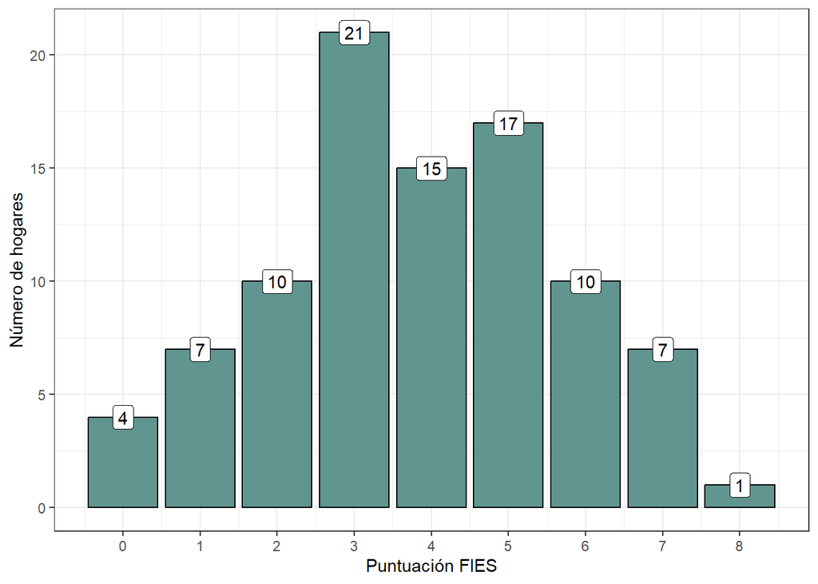

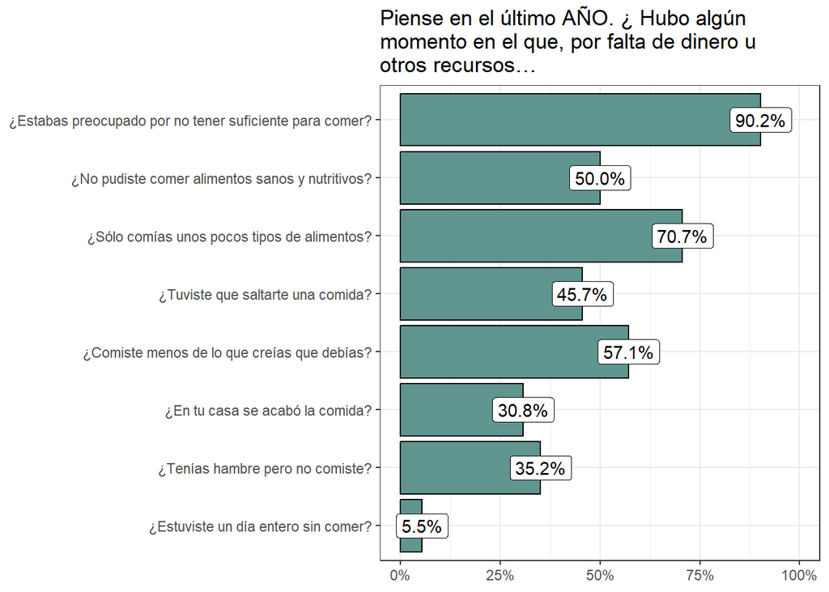